# Data Visualization Using `plotnine`

The Palmer Penguins dataset had a variety of column types with which to explore some nice visualizations. The `mtcars` dataset is another popular dataset for doing some simple data work, but does not contain the same types of variables.

Run the following code to load the `mtcars` dataset and explore the observations and variables contained within. To learn more about this dataset check out [this site](https://stat.ethz.ch/R-manual/R-devel/library/datasets/html/mtcars.html)

```python
import statsmodels.api as sm
import pandas as pd
import plotnine as pn
from plotnine import *
mtcars = sm.datasets.get_rdataset("mtcars", "datasets", cache=True).data
df = pd.DataFrame(mtcars)
```

```python
df
```

The statement "the `mtcars` dataset does not contain the same types of variables as the penguins dataset" is a little true and a little false. There are no variables that contain text values, BUT there are variables that it makes sense to consider categorical variables. In most situations, it makes sense to treat the values of categorical variables as text values instead of numeric values.

Use the `astype()` method to convert the categorical variables of the `mtcars` (df) dataset to have text values in the code chunk below. We've done one for you!

```python
df["am"] = df["am"].astype(str)
df["mpg"]= df["mpg"].astype(str)
df["cyl"]= df["cyl"].astype(str)
df["disp"]=df["disp"].astype(str)
df["hp"]=df["hp"].astype(str)
df["drat"]=df["drat"].astype(str)
df["wt"]=df["wt"].astype(str)
df["qsec"]=df["qsec"].astype(str)
df["carb"]=df["carb"].astype(str)
df["gear"]=df["gear"].astype(str)
df["vs"]=df["vs"].astype(str)
print(df)
# Convert the other variables below
```

```
                      mpg cyl   disp   hp  drat     wt   qsec vs am gear carb
rownames
Mazda RX4            21.0   6  160.0  110   3.9   2.62  16.46  0  1    4    4
Mazda RX4 Wag        21.0   6  160.0  110   3.9  2.875  17.02  0  1    4    4
Datsun 710           22.8   4  108.0   93  3.85   2.32  18.61  1  1    4    1
Hornet 4 Drive       21.4   6  258.0  110  3.08  3.215  19.44  1  0    3    1
Hornet Sportabout    18.7   8  360.0  175  3.15   3.44  17.02  0  0    3    2
Valiant              18.1   6  225.0  105  2.76   3.46  20.22  1  0    3    1
Duster 360           14.3   8  360.0  245  3.21   3.57  15.84  0  0    3    4
Merc 240D            24.4   4  146.7   62  3.69   3.19   20.0  1  0    4    2
Merc 230             22.8   4  140.8   95  3.92   3.15   22.9  1  0    4    2
Merc 280             19.2   6  167.6  123  3.92   3.44   18.3  1  0    4    4
Merc 280C            17.8   6  167.6  123  3.92   3.44   18.9  1  0    4    4
Merc 450SE           16.4   8  275.8  180  3.07   4.07   17.4  0  0    3    3
Merc 450SL           17.3   8  275.8  180  3.07   3.73   17.6  0  0    3    3
Merc 450SLC          15.2   8  275.8  180  3.07   3.78   18.0  0  0    3    3
Cadillac Fleetwood   10.4   8  472.0  205  2.93   5.25  17.98  0  0    3    4
Lincoln Continental  10.4   8  460.0  215   3.0  5.424  17.82  0  0    3    4
Chrysler Imperial    14.7   8  440.0  230  3.23  5.345  17.42  0  0    3    4
Fiat 128             32.4   4   78.7   66  4.08    2.2  19.47  1  1    4    1
Honda Civic          30.4   4   75.7   52  4.93  1.615  18.52  1  1    4    2
Toyota Corolla       33.9   4   71.1   65  4.22  1.835   19.9  1  1    4    1
Toyota Corona        21.5   4  120.1   97   3.7  2.465  20.01  1  0    3    1
Dodge Challenger     15.5   8  318.0  150  2.76   3.52  16.87  0  0    3    2
AMC Javelin          15.2   8  304.0  150  3.15  3.435   17.3  0  0    3    2
Camaro Z28           13.3   8  350.0  245  3.73   3.84  15.41  0  0    3    4
Pontiac Firebird     19.2   8  400.0  175  3.08  3.845  17.05  0  0    3    2
Fiat X1-9            27.3   4   79.0   66  4.08  1.935   18.9  1  1    4    1
Porsche 914-2        26.0   4  120.3   91  4.43   2.14   16.7  0  1    5    2
Lotus Europa         30.4   4   95.1  113  3.77  1.513   16.9  1  1    5    2
Ford Pantera L       15.8   8  351.0  264  4.22   3.17   14.5  0  1    5    4
Ferrari Dino         19.7   6  145.0  175  3.62   2.77   15.5  0  1    5    6
Maserati Bora        15.0   8  301.0  335  3.54   3.57   14.6  0  1    5    8
Volvo 142E           21.4   4  121.0  109  4.11   2.78   18.6  1  1    4    2
```

If you print out your new dataset, is it clear that the variables have been converted to text values? If so, how can you tell?

It should also be clear by how `plotnine` treats these variables.

1. Create side-by-side boxplots of the `mpg` variable by the different values of the `am` variable. What happens if you convert the `am` variable back to float values and then try to create this same plot? Explain the differences between the two plots.
2. Create overlaid histograms of the `hp` variable for the different values of the `cyl` variable. What happens if you convert the `cyl` variable back to float values and then try to create this same plot? Explain the differences between the two plots.

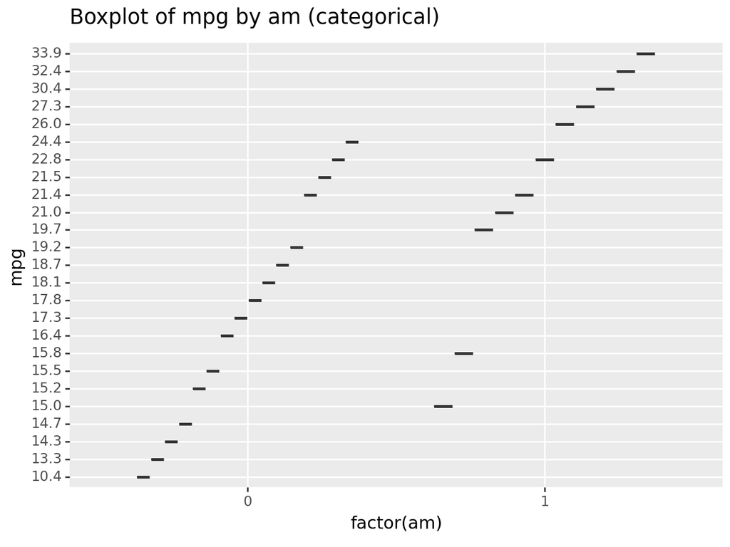

```python
# Create plot for (1) here
boxplot_categorical = (
    pn.ggplot(df, aes(x='factor(am)', y='mpg'))
    + geom_boxplot()
    + labs(title="Boxplot of mpg by am (categorical)")
)

print(boxplot_categorical)
```

```python
df['am'] = df['am'].astype(float)
```

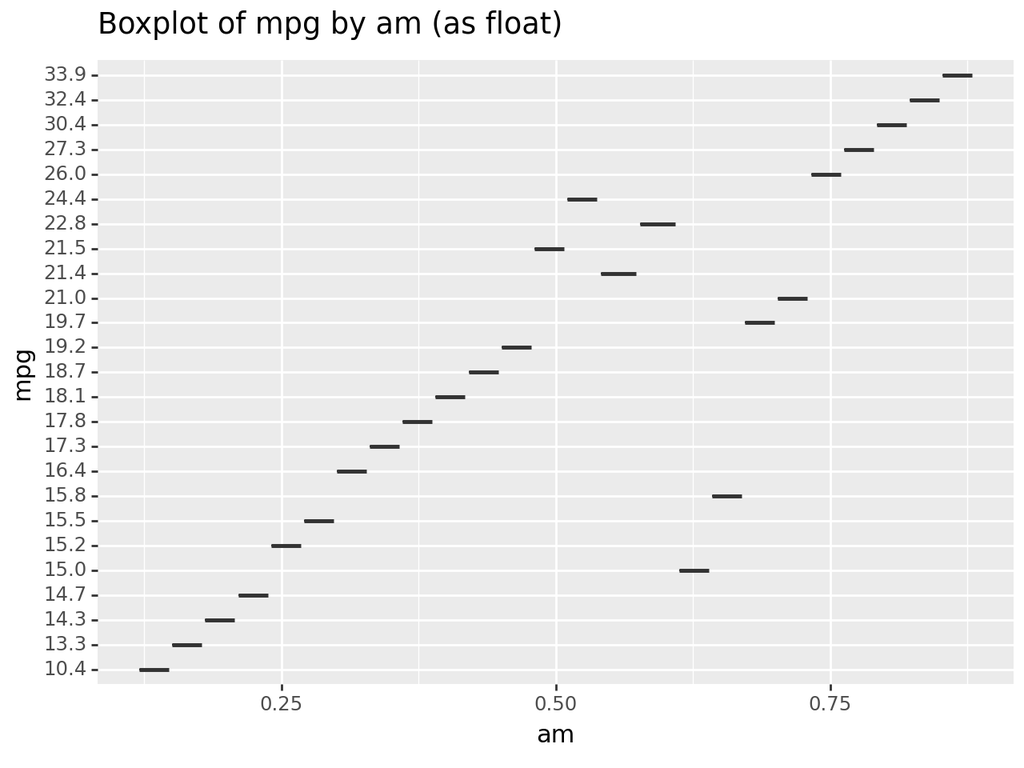

```python
boxplot_float = (
    pn.ggplot(df, aes(x='am', y='mpg'))
    + geom_boxplot()
    + labs(title="Boxplot of mpg by am (as float)")
)

print(boxplot_float)
```

The differences come in the units of the x-axis, where the values are treated as a continuous variable and the plot represents the variation in mpg for all values from 0 to 1

[figure not shown]

```python
# Create plot for (2) here
histogram_categorical = (
    pn.ggplot(df, aes(x='hp', fill='factor(cyl)'))
    + geom_histogram(alpha=0.5, bins=10)
    + labs(title="Overlaid Histogram of hp by cyl (categorical)")
)

print(histogram_categorical)
```

```python
df['cyl'] = df['cyl'].astype(float)
```

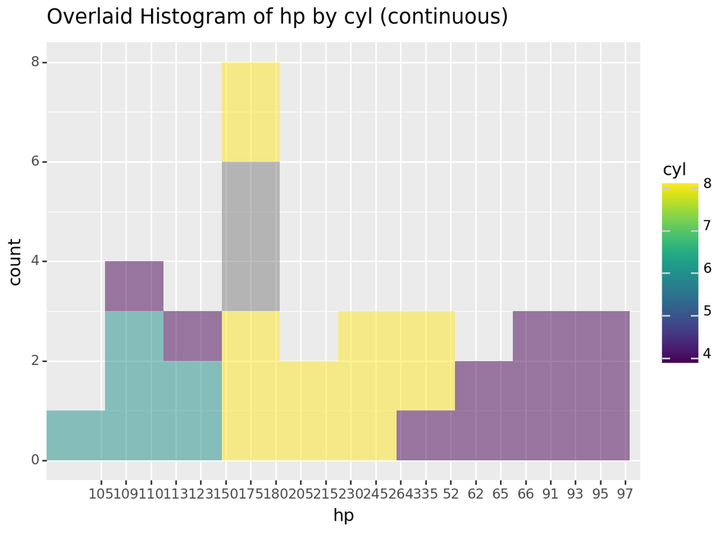

```python
histogram_continuous = (
    pn.ggplot(df, aes(x='hp', fill='cyl'))
    + geom_histogram(alpha=0.5, bins=10)
    + labs(title="Overlaid Histogram of hp by cyl (continuous)")
)

print(histogram_continuous)
```

The factors are different, and there is overlap in the second plot with cyl as a continuous variable.

:Some of these variables, like the `cyl` variable, have numeric values that actually make sense as numbers (i.e. the number of cylinders in the engine). However, it doesn't make the most sense to "do math" with this type of variable (e.g. take averages and such) because there are so few different value this can take on AND they're an explicit choice made by the car manufacturer. So, it makes more sense to treat the `cyl` variable as a categorical variable despite it having numeric values.

You will need to keep these kinds of nuances about data in mind as you work with an increasing variety and richness of data, and do more complex things with them.

Choose 3 new `geometries` from the [data-to-viz website](https://www.data-to-viz.com/) for graphs that you'd like to explore using the `mtcars` dataset, and then create those graphs!

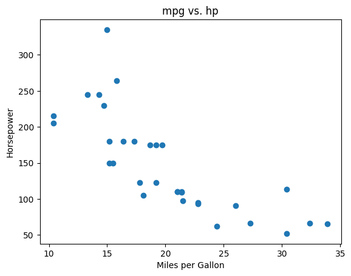

```python
import matplotlib.pyplot as plt
import statsmodels.api as sm

mtcars = sm.datasets.get_rdataset("mtcars").data

plt.scatter(mtcars['mpg'], mtcars['hp'])

plt.xlabel('Miles per Gallon')
plt.ylabel('Horsepower')
plt.title('mpg vs. hp')

plt.show()
```

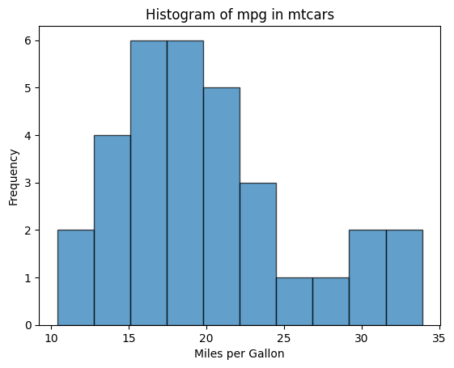

```python
import matplotlib.pyplot as plt
import statsmodels.api as sm
mtcars = sm.datasets.get_rdataset("mtcars").data

plt.hist(mtcars['mpg'], bins=10, edgecolor='k', alpha=0.7)

plt.xlabel('Miles per Gallon')
plt.ylabel('Frequency')
plt.title('Histogram of mpg in mtcars')

plt.show()
```

[figure not shown]

```python
# Create plot with third new geometry here
import matplotlib.pyplot as plt
import statsmodels.api as sm

mtcars = sm.datasets.get_rdataset("mtcars").data

x = mtcars['mpg']
y = mtcars['hp']
size = mtcars['wt'] * 10
color = mtcars['am']

plt.scatter(x, y, s=size, c=color, cmap='viridis', alpha=0.5, edgecolors='k')

plt.xlabel('Miles per Gallon')
plt.ylabel('Horsepower')
plt.title('Bubble Plot of mpg vs. hp')

plt.colorbar(label='Transmission Type')

plt.show()
```